# Netflix data analysis and visualisation

Importing necessary libraries.

```r
library(dplyr)
library(ggplot2)
library(scales)
```

Importing (reading) the data of Best movies and Shows. Grabbing high-rated movies/shows (min score 6.9)

```r
dataBestMovies <- read.csv("C:/Users/Asus/OneDrive/Desktop/Group project - Netflix/Best Movies Netflix.csv")
dataBestShows <- read.csv("C:/Users/Asus/OneDrive/Desktop/Group project - Netflix/Best Shows Netflix.csv")
```

Exploring data & checking for missing values. Get data overview & identify missing values. Printing summary statistics and checking for missing data. Analyzing data distribution and identifying missing values.

```r
has_missingMovie <- sum(is.na(dataBestMovies)) > 0
has_missingShow <- sum(is.na(dataBestShows)) > 0
dataBestMovies$MAIN_GENRE <- factor(dataBestMovies$MAIN_GENRE)
dataBestMovies$MAIN_PRODUCTION <- factor(dataBestMovies$MAIN_PRODUCTION)
dataBestShows$MAIN_GENRE <- factor(dataBestShows$MAIN_GENRE)
dataBestShows$MAIN_PRODUCTION <- factor(dataBestShows$MAIN_PRODUCTION)
print(summary(dataBestMovies))
```

```
    TITLE            RELEASE_YEAR      SCORE       NUMBER_OF_VOTES
 Length:387         Min.   :1954   Min.   :6.900   Min.   :  10139
 Class :character   1st Qu.:2008   1st Qu.:7.100   1st Qu.:  20513
 Mode  :character   Median :2014   Median :7.400   Median :  45200
                    Mean   :2011   Mean   :7.509   Mean   : 136521
                    3rd Qu.:2018   3rd Qu.:7.800   3rd Qu.: 153486
                    Max.   :2022   Max.   :9.000   Max.   :2268288

    DURATION           MAIN_GENRE  MAIN_PRODUCTION
 Min.   : 28.0   drama      :151   US     :157
 1st Qu.:103.5   thriller   : 59   IN     :115
 Median :122.0   comedy     : 58   GB     : 29
 Mean   :123.4   crime      : 21   DE     :  9
 3rd Qu.:139.0   romance    : 21   JP     :  9
 Max.   :229.0   documentary: 20   FR     :  7
                 (Other)    : 57   (Other): 61
```

```r
print(summary(dataBestShows))
```

```
    TITLE            RELEASE_YEAR      SCORE       NUMBER_OF_VOTES
 Length:246         Min.   :1969   Min.   :7.500   Min.   :  10024
 Class :character   1st Qu.:2013   1st Qu.:7.700   1st Qu.:  18553
 Mode  :character   Median :2016   Median :8.000   Median :  41943
                    Mean   :2015   Mean   :8.093   Mean   : 101967
                    3rd Qu.:2019   3rd Qu.:8.400   3rd Qu.: 112812
                    Max.   :2022   Max.   :9.500   Max.   :1727694

    DURATION      NUMBER_OF_SEASONS   MAIN_GENRE MAIN_PRODUCTION
 Min.   : 16.00   Min.   : 1.00     drama  :82   US     :134
 1st Qu.: 27.25   1st Qu.: 1.00     scifi  :45   GB     : 27
 Median : 44.00   Median : 3.00     comedy :43   JP     : 26
 Mean   : 41.92   Mean   : 3.65     action :28   CA     : 13
 3rd Qu.: 51.75   3rd Qu.: 5.00     crime  :20   KR     :  9
 Max.   :141.00   Max.   :21.00     war    : 8   DE     :  5
                                    (Other):20   (Other): 32
```

This code block converts the release dates of movies and shows into their corresponding decades. This will likely be used for further analysis where grouping by decade is important.

```r
group_by_date <- function(DOF) {
  start_decade <- seq(from = 1980, to = 2020, by = 10)
  end_decade <- start_decade + 9
  for (i in length(start_decade):1) {
    if (DOF >= start_decade[i] & DOF < end_decade[i]) {
      decade <- paste0(start_decade[i], 's')
      return (decade)
    }
  }
  if (DOF < start_decade[1]) {
    return("Released before 1980")
  } else {
    return ("Released after 2020")
  }
}
```

Implement DECADES column derived from *group_by_date* function.

```r
dataBestMovies$DECADES <- sapply(dataBestMovies$RELEASE_YEAR, group_by_date)
dataBestShows$DECADES <- sapply(dataBestShows$RELEASE_YEAR, group_by_date)
```

Calculating the average score, number of movies for each decade and main genre combination.

```r
grouppedMovies <- dataBestMovies %>%
  group_by(MAIN_GENRE, DECADES) %>%
  summarise(SCORE = mean(SCORE),
            COUNT_OF_MOVIES = n())
grouppedShows <- dataBestShows %>%
  group_by(MAIN_GENRE, DECADES) %>%
  summarise(SCORE = mean(SCORE),
            COUNT_OF_SHOWS = n())
```

Visualization of Movies

Popularity of movie genres across different decades using pie charts. Each pie chart will represent a specific decade, with slices depicting the proportion of movies belonging to various genres. This visualization will highlight the dominant genres favored by producers throughout time, with a particular focus on Drama’s position as the “absolute champion.”

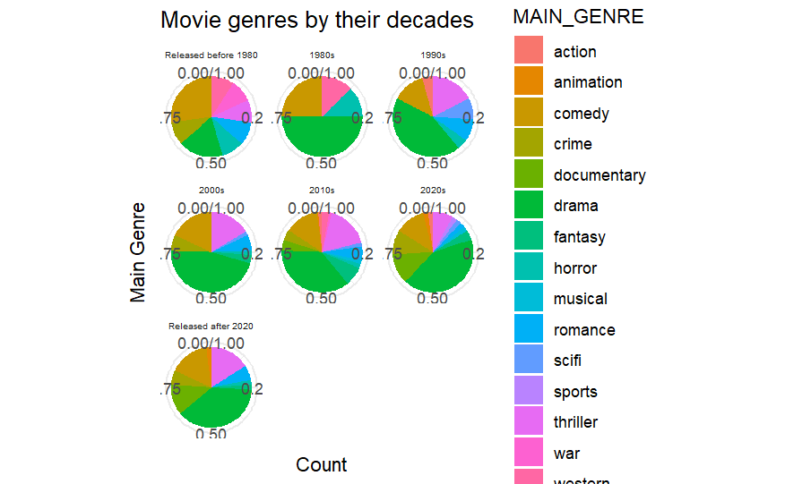

```r
grouppedMovies$DECADES <- factor(grouppedMovies$DECADES, levels = c("Released before 1980", "1980s", "1990s", "2000s", "2010s", "2020s", "Released after 2020"))

ggplot(data = grouppedMovies, aes(x = "", y = COUNT_OF_MOVIES, fill = MAIN_GENRE)) +
  geom_col(width = 1, position = 'fill') +
  facet_wrap(.~DECADES, nrow=3, ncol = 3) +
  labs(title = "Movie genres by their decades",
       x = "Main Genre",
       y = "Count") +
  scale_x_discrete() +
  coord_polar(theta = "y", start = 0) +
  theme_minimal() +
  theme(strip.text.x = element_text(size = 5))
```

Science fiction, westerns, horror, and crime emerge as the top four most popular genres in your analysis. This variety suggests a broad audience interest across genres that explore imaginative worlds, historical settings, thrilling suspense, and complex characters.The variable that is chosen for this analysis is the number of votes.

```r
voters_favourite_Ms <- dataBestMovies %>%
  group_by(MAIN_GENRE) %>%
  summarise(AVERAGE_VOTERS = mean(NUMBER_OF_VOTES),
            SCORE = max(SCORE)) %>%
  arrange(desc(AVERAGE_VOTERS)) %>%
  head(4)

print(voters_favourite_Ms)
```

| MAIN_GENRE | AVERAGE_VOTERS | SCORE |
| --- | --- | --- |
| scifi | 547524.4 | 8.8 |
| western | 395729.9 | 8.4 |
| horror | 219894.2 | 8.1 |
| crime | 183700.5 | 8.4 |

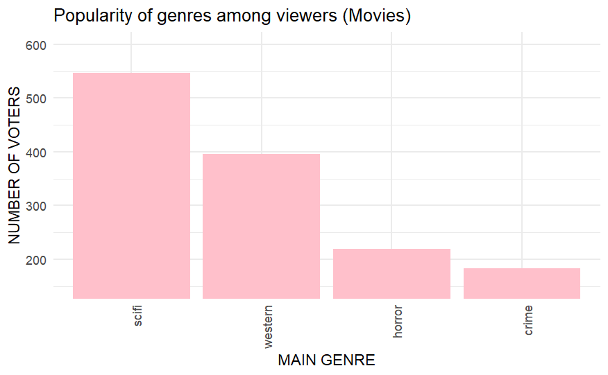

```r
ggplot(data = voters_favourite_Ms, aes(x = reorder(MAIN_GENRE, -AVERAGE_VOTERS), y = AVERAGE_VOTERS/1000)) +
  geom_bar(fill = "pink", stat = "identity") +
  labs(title = "Popularity of genres among viewers (Movies)",
       x = "MAIN GENRE", y = "NUMBER OF VOTERS") +
  coord_cartesian(ylim = c(150, 600)) +
  theme_minimal() +
  theme(axis.text.x = element_text(angle = 90, hjust = 1))
```